# Laboratory 6

Simulation, examples and exercises

Spring 2020

# Generalized additive models (GAM)

A generalized additive model (GAM) is a generalized linear model (GLM) in which the linear predictor is given by a user specified sum of smooth functions of the covariates plus a conventional parametric component of the linear predictor. Given $\mu_i=E[Y_i]$, a simple example is:

$$\log(\mu_i)= \beta_0+\sum_{j=1}^{p}s_j(x_{ij})+\epsilon_i, \ i=1,\ldots,n,$$
where the dependent variable $Y_{i} \sim \mathsf{Gamma}(\mu_i, \phi)$ and $s_j$ are smooth functions of covariates $x_j$. GAM models imply the following **likelihood penalization**

$$l(\boldsymbol{\beta}, \boldsymbol{s})-\lambda R(\boldsymbol{s}),$$

where $R(\boldsymbol{s})$ is a measure of roughness.

- if $\lambda \rightarrow \infty \Rightarrow$ **maximal smoothness**. The fitted curve $s(\cdot)$ is a straight line. The *effective number of parameters* associated to the predictor $x_j$ is 1. No need for a smooth function.
- if $\lambda \rightarrow 0\Rightarrow$ **no smoothness**. No penalty is considered and the *effective number of parameters* associated to the predictor $x_j$ is greater than 1.

## Trees dataset

As an example, consider the simple dataset `trees`, where we have measurements of the girth, height and volume of timber in 31 felled black cherry trees. Note that girth is the diameter of the tree (in inches) measured at 4 ft 6 in above the ground. First of all, we use the `pairs` plot for checking possible correlations between the three variables.

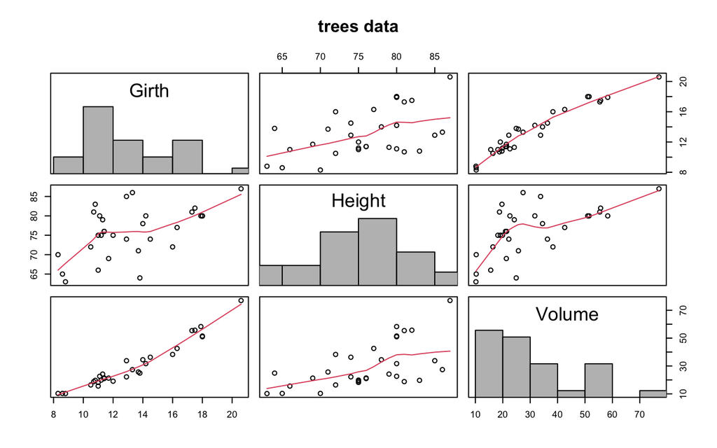

### The model

In order to give a general idea about the GAM flexibility, we may start with one predictor. We could fit a simple Generalized Linear Model (GLM), and a GAM model $Y_{i} \sim \mathsf{Gamma}(\mu_i, \phi)$, such that:

$$\begin{align*}
\log(\mu_i)= & \beta_0+\beta_1 \mathsf{Height}_i\\
\log(\mu_i)= & \beta_0+ s_1(\mathsf{Height}_i),
\end{align*}$$

for $i=1,\ldots,n$. The question we pose is whether the GLM structure is good enough for fitting these data. We could start by printing the output of the GAM model; then, we may plot the predicted values for both the models.

```r
glm.1 <- glm(Volume ~ Height, family = Gamma(link=log), data=trees)
gam.1 <- gam(Volume ~ s(Height), family=Gamma(link=log), data=trees)

summary(gam.1)
```

```
##
## Family: Gamma
## Link function: log
##
## Formula:
## Volume ~ s(Height)
##
## Parametric coefficients:
##             Estimate Std. Error t value Pr(>|t|)
## (Intercept)  3.34970    0.07236   46.29   <2e-16 ***
## ---
## Signif. codes:  0 '***' 0.001 '**' 0.01 '*' 0.05 '.' 0.1 ' ' 1
##
## Approximate significance of smooth terms:
##           edf Ref.df     F  p-value
## s(Height)   1      1 22.97 3.68e-05 ***
## ---
## Signif. codes:  0 '***' 0.001 '**' 0.01 '*' 0.05 '.' 0.1 ' ' 1
##
## R-sq.(adj) =  0.348   Deviance explained = 42.6%
## GCV = 0.17591  Scale est. = 0.1623    n = 31
```

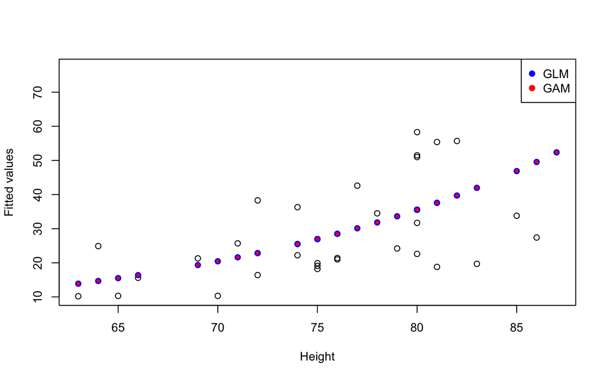

```r
plot(trees$Height, trees$Volume, xlab="Height", ylab="Fitted values")
points(trees$Height, glm.1$fitted.values, col="blue", bg=3, pch=19)
points(trees$Height, gam.1$fitted.values, col="red", bg=2, pch=19, cex=.5)
legend("topright", c("GLM","GAM"), pch=19, col=c("blue", "red"))
```

Diagnostic plot involve the representation of the smooth function and the partial residuals defined as:
$$\hat\epsilon^{part}_{ij}=\hat s_j(x_{ij})+\hat\epsilon_i^{P}$$
where $\hat\epsilon^{P}$ are the Pearson residuals of the model. Looking at this plot we are interested in noticing non linearity or wiggle behavior of the smooth function and if the partial residuals are evenly distributed around the function.

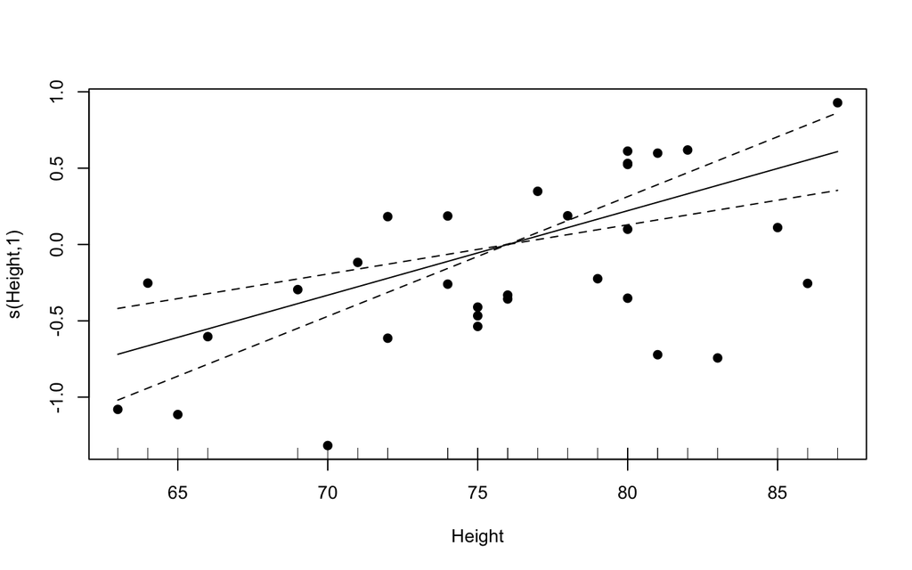

```r
plot(gam.1,residuals=TRUE,pch=19)
```

By the joint analysis of the summary output—look at the value `edf=1`—the prediction plots and the final plot displaying $s(\mathsf{Height})$ versus $\mathsf{Height}$, we may conclude that this simple single predictor framework may be well explained by a GLM approach.

### Adding another predictor

Consider now to add the predictor $\mathsf{Girth}$, and take the same model as before, $Y_{i}=\mathsf{Volume}_i\sim \mathsf{Gamma}(\mu_i, \phi)$, then:

$$\log(\mu_i)=s_1(\mathsf{Height}_i)+s_2(\mathsf{Girth}_i).$$
Analogously as before, we fit the GLM and the GAM model. We plot together the fitted values and we separately analyze the smooth terms $s_1(\mathsf{Height})$ and $s_2(\mathsf{Girth})$.

```r
glm.2<-glm(Volume ~ Girth + Height, family = Gamma(link=log), data=trees)
gam.2 <- gam(Volume ~ s(Height) + s(Girth), family=Gamma(link=log), data=trees)
summary(gam.2)
```

```
##
## Family: Gamma
## Link function: log
##
## Formula:
## Volume ~ s(Height) + s(Girth)
##
## Parametric coefficients:
##             Estimate Std. Error t value Pr(>|t|)
## (Intercept)  3.27570    0.01492   219.6   <2e-16 ***
## ---
## Signif. codes:  0 '***' 0.001 '**' 0.01 '*' 0.05 '.' 0.1 ' ' 1
##
## Approximate significance of smooth terms:
##             edf Ref.df      F  p-value
## s(Height) 1.000  1.000  31.32 3.92e-06 ***
## s(Girth)  2.422  3.044 219.28  < 2e-16 ***
## ---
## Signif. codes:  0 '***' 0.001 '**' 0.01 '*' 0.05 '.' 0.1 ' ' 1
##
## R-sq.(adj) =  0.973   Deviance explained = 97.8%
## GCV = 0.0080824  Scale est. = 0.006899  n = 31
```

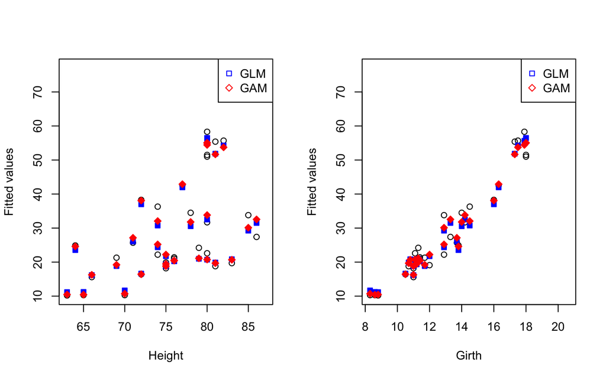

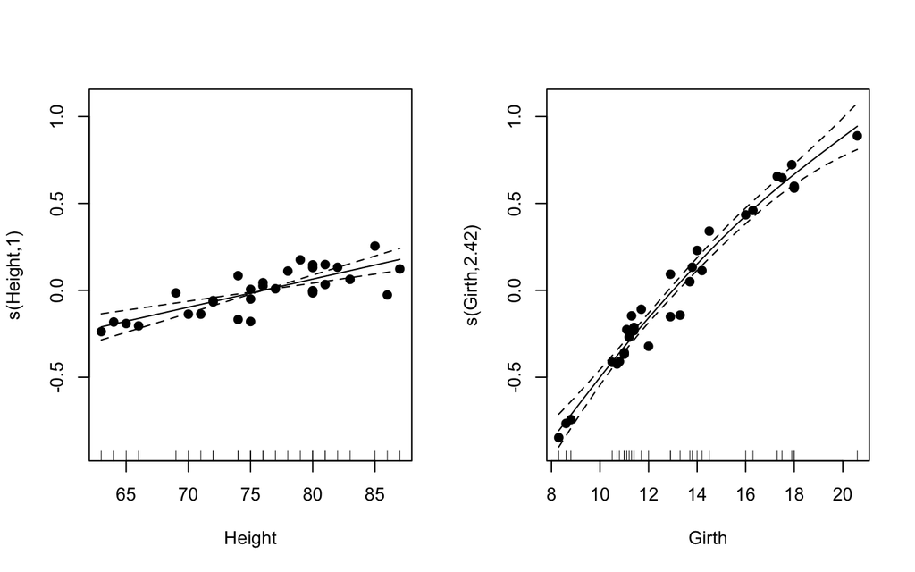

Options to visualize the fitted surface are collected in the function `vis.gam` which offers perspective and contour plot for a gam model.

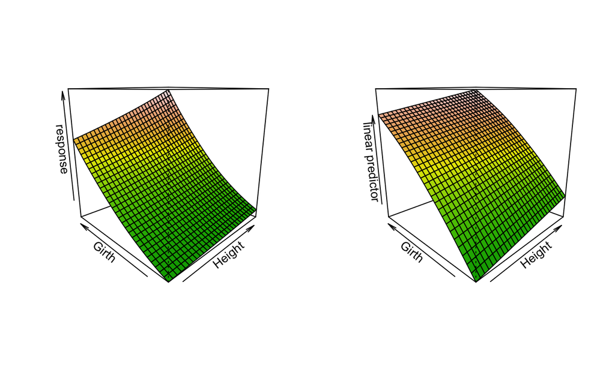

```r
par(mfrow=c(1,2))
vis.gam(gam.2,theta=-45,type = "response", color="terrain")
vis.gam(gam.2,theta=-45,type = "link", color="terrain")
```

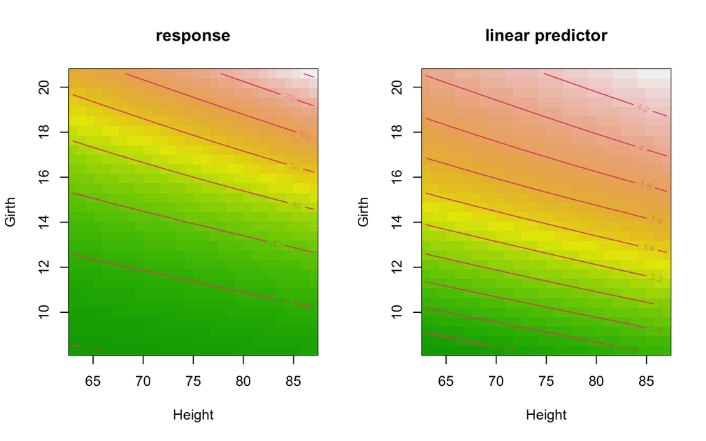

```r
par(mfrow=c(1,2))
vis.gam(gam.2,type = "response", color="terrain", plot.type = "contour")
vis.gam(gam.2,type = "link", color="terrain", plot.type = "contour")
```

The output reports an `edf` equals 2.422 for the $\mathsf{Girth}$ predictor, meaning that a straight line could be partially inappropriate for our purposes. As a further check, we may compute the AIC for the four proposed models:

```r
AIC(glm.1, gam.1, glm.2, gam.2)
```

```
##             df      AIC
## glm.1 3.000000 239.6724
## gam.1 3.000009 239.6724
## glm.2 4.000000 151.0081
## gam.2 5.422254 142.8559
```

The AIC for the single predictor models coincide. The AIC dramatically decreases when considering the second predictor, with the GAM model favorite over the GLM model.

An issue we should consider is the so called **optimal degree of smoothness**. With the argument `sp` in the `gam` function we can manually control the degree of smoothness for each smooth function included in the model.

```r
#unpenalized regression spline
gam.2.1 <- gam(Volume ~ s(Height, k=10, fx=TRUE)+
                 s(Girth, k=10, fx=TRUE),
               family=Gamma(link=log), data=trees)
gam.2.1$sp
```

```
## named numeric(0)
```

```r
summary(gam.2.1)
```

```
##
## Family: Gamma
## Link function: log
##
## Formula:
## Volume ~ s(Height, k = 10, fx = TRUE) + s(Girth, k = 10, fx = TRUE)
##
## Parametric coefficients:
##             Estimate Std. Error t value Pr(>|t|)
## (Intercept)  3.27370    0.01261   259.6   <2e-16 ***
## ---
## Signif. codes:  0 '***' 0.001 '**' 0.01 '*' 0.05 '.' 0.1 ' ' 1
##
## Approximate significance of smooth terms:
##           edf Ref.df      F  p-value
## s(Height)   9      9  5.885  0.00295 **
## s(Girth)    9      9 85.247 1.72e-09 ***
## ---
## Signif. codes:  0 '***' 0.001 '**' 0.01 '*' 0.05 '.' 0.1 ' ' 1
##
## R-sq.(adj) =  0.983   Deviance explained = 99.3%
## GCV = 0.012894  Scale est. = 0.0049312  n = 31
```

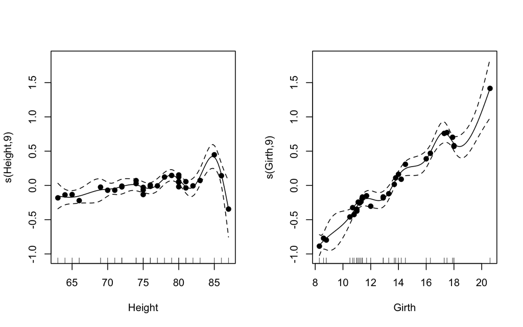

```r
par(mfrow=c(1,2))
plot(gam.2.1,residuals=TRUE,pch=19)
```

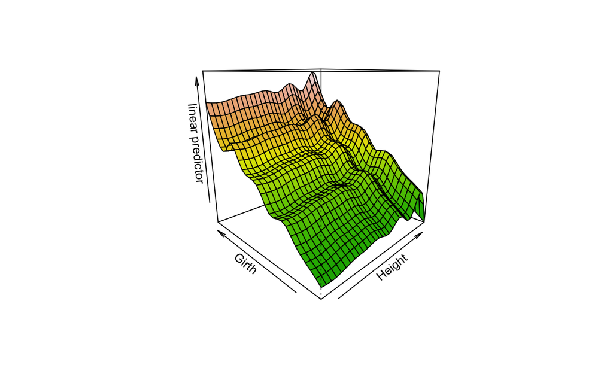

```r
par(mfrow=c(1,1))
vis.gam(gam.2.1,theta=-45,type = "link", color="terrain")
```

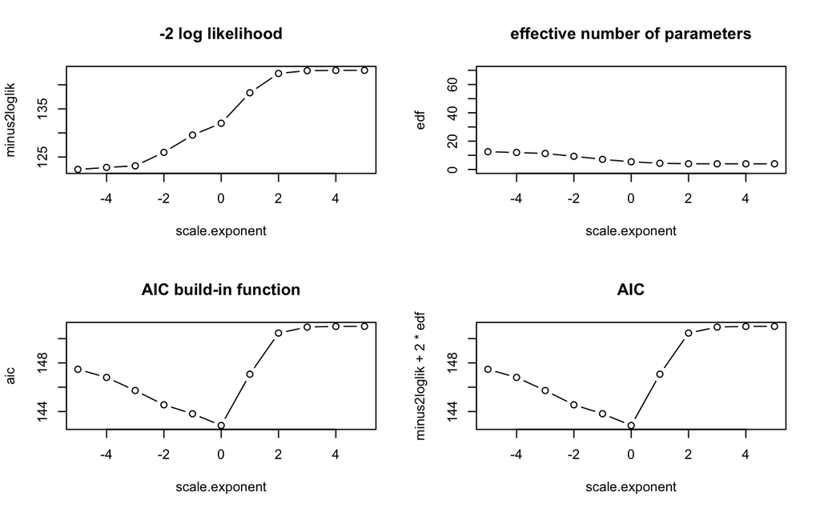

```r
#extract the values
sp <- gam.2$sp

tuning.scale<-c(1e-5,1e-4,1e-3,1e-2,1e-1,1e0,1e1,1e2,1e3,1e4,1e5)
scale.exponent <- log10(tuning.scale)
n.tuning <- length(tuning.scale)

minus2loglik <- rep(NA,n.tuning)
edf <- rep(NA,n.tuning)
aic <- rep(NA,n.tuning)


for (i in 1:n.tuning) {
  gamobj <- gam(Volume ~ s(Height) + s(Girth), family=Gamma(link=log),
                data=trees, sp=tuning.scale[i]*sp)
  minus2loglik[i] <- -2*logLik(gamobj)
  edf[i]          <- sum(gamobj$edf)+1
  aic[i]          <- AIC(gamobj)
}

par(mfrow=c(2,2))
plot(scale.exponent,minus2loglik,type="b",main="-2 log likelihood")
plot(scale.exponent,edf,ylim=c(0,70),type="b",main="effective number of parameters")
plot(scale.exponent,aic,type="b",main="AIC build-in function")
plot(scale.exponent,minus2loglik+2*edf,type="b",main="AIC")
```

```r
# find the minimum
opt.tuning.scale <- tuning.scale[which.min(aic)]
opt.tuning.scale
```

```
## [1] 1
```

```r
opt.sp<-opt.tuning.scale*sp

# fitting the final model with the optimal level of smoothing

gam.2.opt <- gam(Volume ~ s(Height)+s(Girth), family=Gamma(link=log),data=trees,
                 sp=opt.sp)

AIC(gam.2, gam.2.opt)
```

```
##                 df      AIC
## gam.2     5.422254 142.8559
## gam.2.opt 5.422254 142.8559
```

**It’s your turn!**

1- Simulate some Poisson data with the `gamSim` function contained in the `mgcv` package (Use the default arguments `eg=1` for the Gu and Wahba 4 univariate term example and `scale=0.1`).

2- Fit a Gam and print the results. Interpret the fit.

3- Produce some plots for each $x_j$ plotted against $s(x_j)$, and comment. Do you maybe drop some covariates?

4- Compute the AIC between your final gam and a glm.

# Tree-based classification

We consider the example of detection of email spam. Data are available from the UCI repository of machine learning databases (http://www.ics.uci.edu/~mlearn/MLRepository.html) and they collect informations about 4601 email items, 1813 classified as spam. 57 explanatory variables describe several characteristics of the data. Following the example in the Data Analyisis and Graphics using R, we will consider only 6 of them, mostly related to the frequency of specific words and characters in the email. In detail,

- `crl.tot`: total length of words that are in capitals;
- `dollar`: the frequency of the $ symbol, as a percentage of all characters;
- `bang`: the frequency of the ! symbol, as a percentage of all characters;
- `money`: frequency of the word “money”, as a percentage of all words;
- `n000`: frequency of the character string “000”, as a percentage of all words;
- `make`: frequency of the word “make”, as a percentage of all words.

Using these 6 explanatory variables we want to build an decision tree model that is able to classify each email correctly as spam (`y` in the binary outcome variable `yesno`) and non-spam (`n` in the binary outcome variable `yesno`).

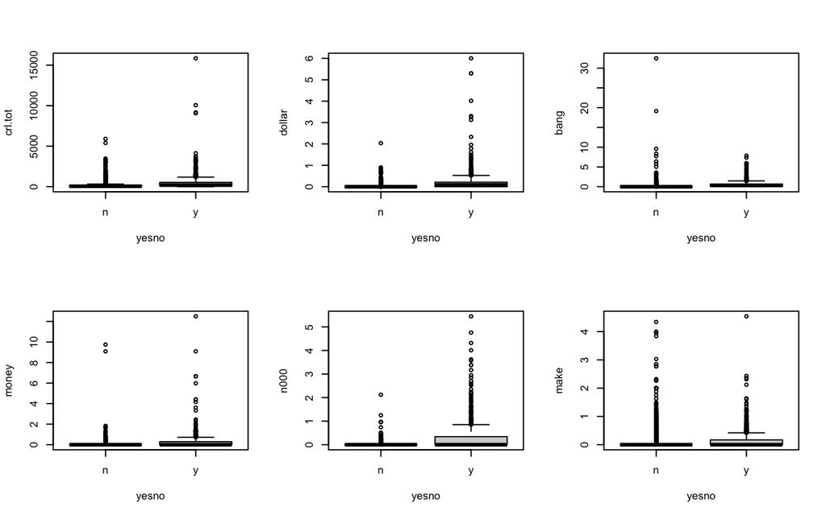

```r
library(reshape2)
library(rpart)
library(rpart.plot)
spam <- read.table("spambase.data", sep=",")
spam <- spam[,c(58,#"yesno"
                57,#"crl.tot"
                53,#"dollar"
                52,#"bang"
                24,#"money"
                23,#"n000"
                1  #"make"
                )]
colnames(spam) <- c("yesno","crl.tot","dollar","bang", "money","n000", "make")
spam$yesno <- factor(spam$yesno, levels = c(0, 1))
levels(spam$yesno) <- c("n","y")

par(mfrow=c(2,3))
for(i in 2:7){
  boxplot(spam[,i]~yesno, data=spam, ylab = colnames(spam)[i])
}
```

```r
#summary(glm(yesno ~ crl.tot + dollar + bang + money + n000 + log(make+.5),
#            family=binomial, data=spam))
```

The model can be fitted using the function `rpart` in the library `rpart`. The option class in the method is selected by default when the outcome variable is of type factor.

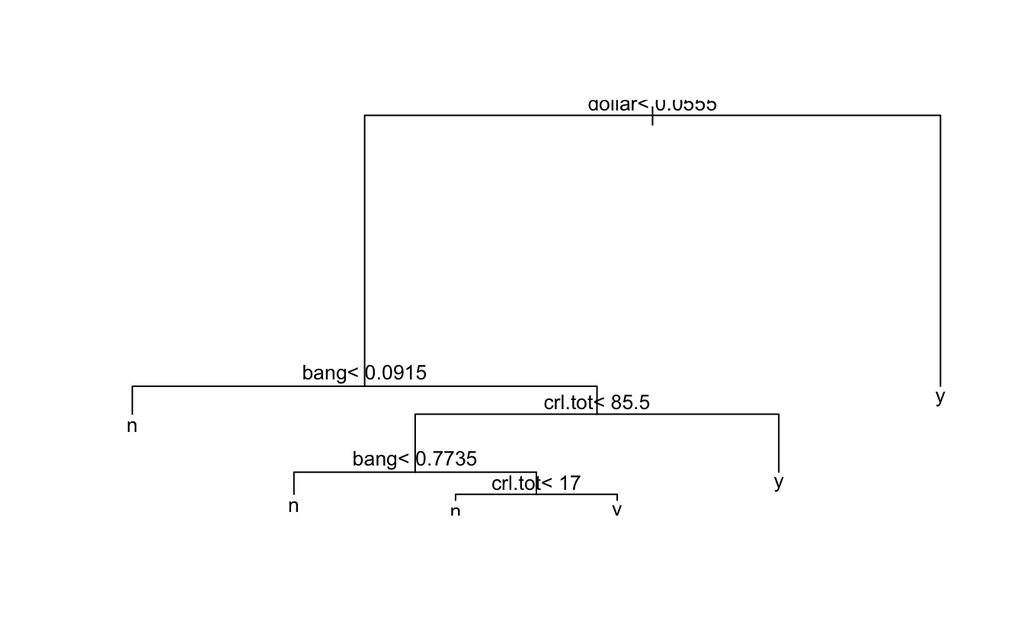

```r
library(rpart)

spam.rpart <- rpart(yesno ~ crl.tot + dollar + bang + money + n000 + make,
                    method="class", data=spam)
plot(spam.rpart) # Draw tree
text(spam.rpart) # Add labeling
```

The summary of the fitted decision tree is visualized using the function `printcp`.

```r
printcp(spam.rpart)
```

```
##
## Classification tree:
## rpart(formula = yesno ~ crl.tot + dollar + bang + money + n000 +
##     make, data = spam, method = "class")
##
## Variables actually used in tree construction:
## [1] bang    crl.tot dollar
##
## Root node error: 1813/4601 = 0.39404
##
## n= 4601
##
##         CP nsplit rel error  xerror     xstd
## 1 0.476558      0   1.00000 1.00000 0.018282
## 2 0.075565      1   0.52344 0.54881 0.015403
## 3 0.011583      3   0.37231 0.39162 0.013516
## 4 0.010480      4   0.36073 0.39437 0.013554
## 5 0.010000      5   0.35025 0.39051 0.013500
```

The complexity parameter `CP` is a proxy for the number of splits. In order to avoid too complex trees, the reduction of lack-of-fit for each additional split is evaluated with an increasing cost. When the cost outweights the reduction, the algorithm stops.

Small complexity parameter `CP` leads to large tree and large `CP`leads to small tree. Let’s try to decrease the default `CP` value for our model.

```r
spam.rpart0001 <- rpart(yesno ~ crl.tot + dollar + bang + money + n000 + make,
                    method="class", data=spam, cp = 0)
printcp(spam.rpart0001)
```

```
##
## Classification tree:
## rpart(formula = yesno ~ crl.tot + dollar + bang + money + n000 +
##     make, data = spam, method = "class", cp = 0)
##
## Variables actually used in tree construction:
## [1] bang    crl.tot dollar  make    money   n000
##
## Root node error: 1813/4601 = 0.39404
##
## n= 4601
##
##            CP nsplit rel error  xerror     xstd
## 1  4.7656e-01      0   1.00000 1.00000 0.018282
## 2  7.5565e-02      1   0.52344 0.55047 0.015420
## 3  1.1583e-02      3   0.37231 0.38555 0.013429
## 4  1.0480e-02      4   0.36073 0.38114 0.013366
## 5  6.3431e-03      5   0.35025 0.36073 0.013065
## 6  5.5157e-03     10   0.31660 0.34528 0.012827
## 7  4.4126e-03     11   0.31109 0.34915 0.012887
## 8  3.8610e-03     12   0.30667 0.34142 0.012767
## 9  2.7579e-03     16   0.29123 0.33370 0.012643
## 10 2.2063e-03     17   0.28847 0.33205 0.012617
## 11 1.9305e-03     18   0.28627 0.32984 0.012581
## 12 1.6547e-03     20   0.28240 0.32488 0.012500
## 13 9.1929e-04     25   0.27413 0.33260 0.012626
## 14 8.2736e-04     29   0.26917 0.33591 0.012679
## 15 5.5157e-04     46   0.25427 0.33867 0.012723
## 16 3.3094e-04     48   0.25317 0.34363 0.012801
## 17 2.7579e-04     53   0.25152 0.34253 0.012784
## 18 1.8386e-04     61   0.24931 0.34197 0.012775
## 19 6.8946e-05     64   0.24876 0.35301 0.012947
## 20 0.0000e+00     72   0.24821 0.35301 0.012947
```

The relative error showed in the summary decreases at any additional split, so it is not useful to evaluate the predictive accuracy of the model, while the xerror (which stands for cross-validated relative error) reaches a minimum. Since the xerror is computed using 10-fold cross-validation procedure by default, the values slightly changes everytime we fit a new model. The relative error remains exactly the same.

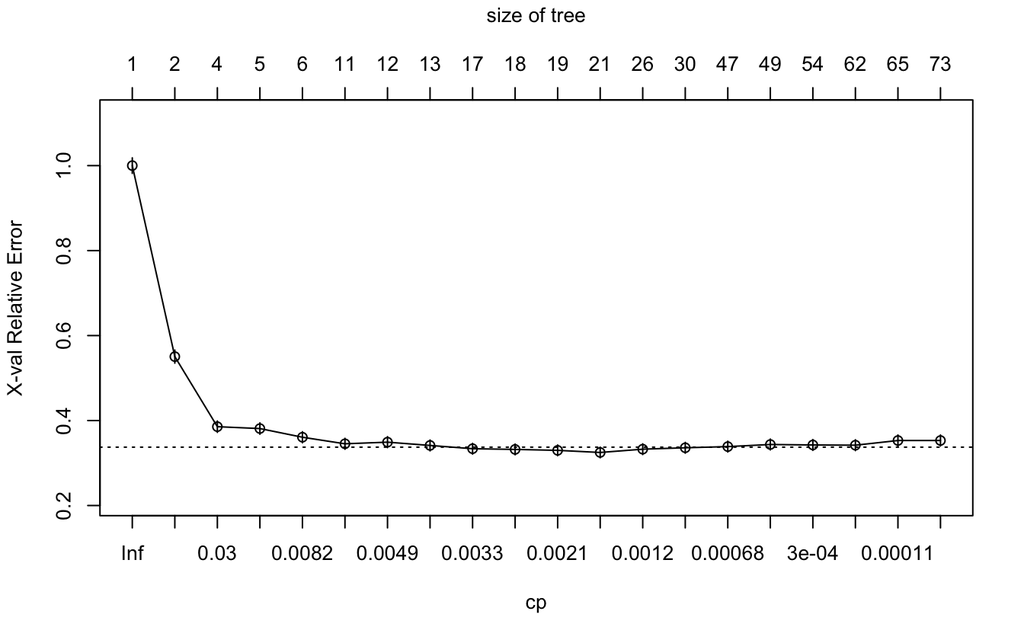

```r
plotcp(spam.rpart0001)
```

Now that we have a very large (overfitted) tree, what is the best number of splits where to prune our tree? Changes in the xerrors are so small that running the model again would probably lead to a different choice of number of splits if it is based on selecting the tree with the absolute minimum xerror. To reduce instabilty in the choice we can use the one-standard-deviation rule. The horizontal dashed line in the plot shows the minimum xerror + standard deviation. So choosing the smallest tree whose xerror is less or equal than this value will lead us to a more conservative choice if the interest is in choosing the optimal predictive tree, i.e., the predictive power will on average be slightly less than optimal.

```r
best.cp <- spam.rpart0001$cptable[which.min(spam.rpart0001$cptable[,"xerror"]),]
best.cp
```

```
##           CP       nsplit    rel error       xerror         xstd
##  0.001654716 20.000000000  0.282404854  0.324875896  0.012500120
```

```r
sd.rule <- best.cp["xerror"]+best.cp["xstd"]
cptable.sd.rule <- spam.rpart0001$cptable[spam.rpart0001$cptable[,"xerror"]<=sd.rule,]
best.cp.sd <- cptable.sd.rule[which.min(cptable.sd.rule[,"nsplit"]),]
best.cp.sd
```

```
##          CP      nsplit   rel error      xerror        xstd
##  0.00275786 16.00000000  0.29123001  0.33370105  0.01264348
```

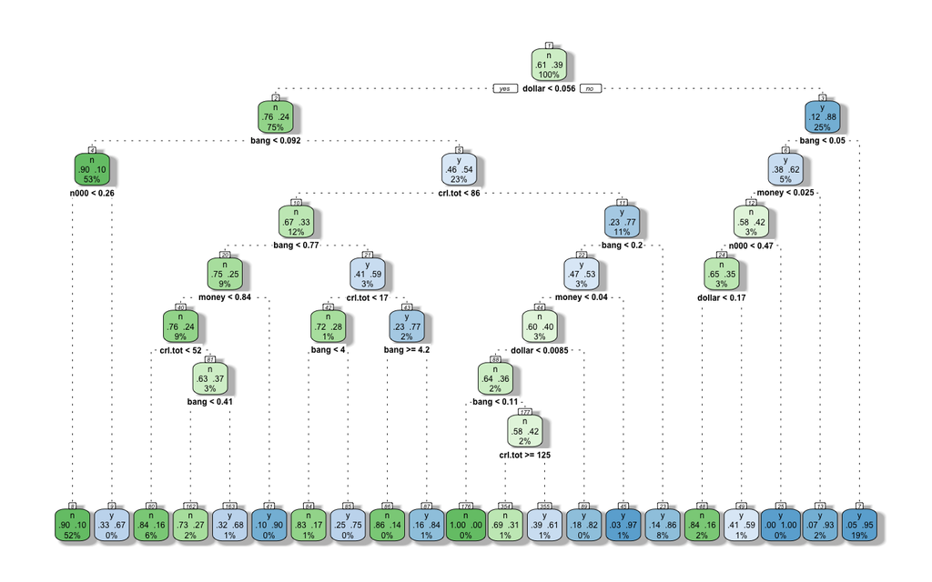

```r
tree.pruned <- prune(spam.rpart0001, cp=best.cp[1])
rpart.plot(tree.pruned, extra=104, box.palette="GnBu",branch.lty=3, shadow.col="gray", nn=TRUE)
```

```r
tree.pruned.sd <- prune(spam.rpart0001, cp=best.cp.sd[1])
printcp(tree.pruned.sd)
```

```
##
## Classification tree:
## rpart(formula = yesno ~ crl.tot + dollar + bang + money + n000 +
##     make, data = spam, method = "class", cp = 0)
##
## Variables actually used in tree construction:
## [1] bang    crl.tot dollar  money   n000
##
## Root node error: 1813/4601 = 0.39404
##
## n= 4601
##
##          CP nsplit rel error  xerror     xstd
## 1 0.4765582      0   1.00000 1.00000 0.018282
## 2 0.0755654      1   0.52344 0.55047 0.015420
## 3 0.0115830      3   0.37231 0.38555 0.013429
## 4 0.0104799      4   0.36073 0.38114 0.013366
## 5 0.0063431      5   0.35025 0.36073 0.013065
## 6 0.0055157     10   0.31660 0.34528 0.012827
## 7 0.0044126     11   0.31109 0.34915 0.012887
## 8 0.0038610     12   0.30667 0.34142 0.012767
## 9 0.0027579     16   0.29123 0.33370 0.012643
```

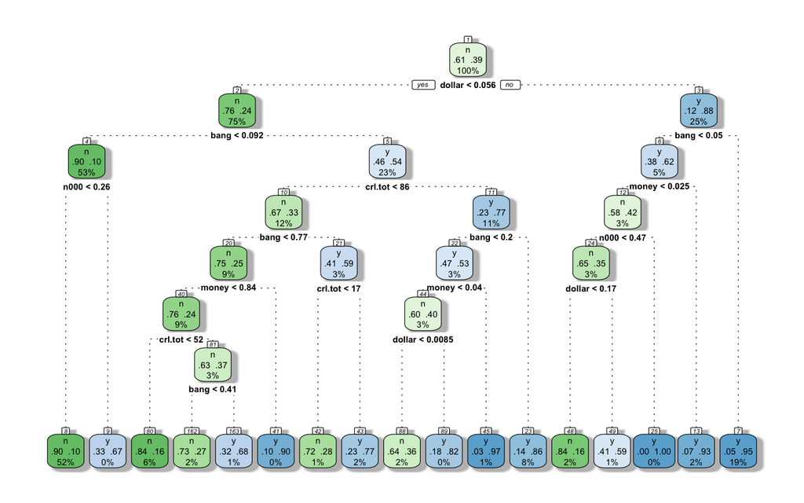

```r
rpart.plot(tree.pruned.sd, extra=104, box.palette="GnBu",branch.lty=3, shadow.col="gray", nn=TRUE)
```

Trying with RandomForest..

```r
library(randomForest)
spam.rf <- randomForest(yesno ~ ., data=spam, importance=TRUE)
print(spam.rf)
```

```
##
## Call:
##  randomForest(formula = yesno ~ ., data = spam, importance = TRUE)
##                Type of random forest: classification
##                      Number of trees: 500
## No. of variables tried at each split: 2
##
##         OOB estimate of  error rate: 11.48%
## Confusion matrix:
##      n    y class.error
## n 2646  142  0.05093257
## y  386 1427  0.21290678
```

```r
importance(spam.rf)
```

```
##                n         y MeanDecreaseAccuracy MeanDecreaseGini
## crl.tot 50.78418  56.57397             73.87111        246.37971
## dollar  55.71155  53.11006             71.89430        414.81805
## bang    94.99250 106.16746            121.03268        609.04757
## money   31.46517  52.88962             51.53528        191.25794
## n000    54.29494  16.19412             58.37293        132.44157
## make    15.14525  22.25584             27.05979         41.87734
```